# Final Codes used

May

[libraries and data import]

### palette for plotting all, assigning variables

### INITIAL INTEREST

[Data wrangling]

[model deciding]

Final model:

```r
initial_int_nbc <- glmer.nb(all_tw_set ~ first_stim -1 + (0+trial_number|Bat_ID),  data = attn_int_2, control=glmerControl(optimizer = "bobyqa"))  #lowest AIC, and most compex random effects structure that makes sense and converges.
#random slope of trial number within bat ID: no variation in intercept
```

Anova

```
## Analysis of Deviance Table (Type II Wald chisquare tests)
##
## Response: all_tw_set
##             Chisq Df Pr(>Chisq)
## first_stim 250.76  7  < 2.2e-16 ***
## ---
## Signif. codes:  0 '***' 0.001 '**' 0.01 '*' 0.05 '.' 0.1 ' ' 1
```

Getting estimates and p-values for differences

```
##  first_stim   lsmean        SE df asymp.LCL asymp.UCL .group
##  De         1.707094 0.2434502 NA  1.229940  2.184248  1
##  T1c        1.709290 0.1959812 NA  1.325174  2.093406  1
##  Ts         1.777063 0.1792599 NA  1.425720  2.128406  1
##  Rt         1.891608 0.2363517 NA  1.428367  2.354849  12
##  Ra         2.028867 0.2371916 NA  1.563980  2.493754  12
##  T2c        2.201060 0.2430208 NA  1.724748  2.677372  12
##  Rra        2.613705 0.2178454 NA  2.186736  3.040674   2
##
## Results are given on the log (not the response) scale.
## Confidence level used: 0.95
## P value adjustment: tukey method for comparing a family of 7 estimates
## significance level used: alpha = 0.05
```

pairwise comparisons:

```
##  contrast      estimate        SE df z.ratio p.value
##  De - Ra   -0.321772856 0.2966774 NA  -1.085  0.9328
##  De - Rra  -0.906610992 0.2917551 NA  -3.107  0.0311
##  De - Rt   -0.184514079 0.3073466 NA  -0.600  0.9968
##  De - T1c  -0.002195745 0.2617150 NA  -0.008  1.0000
##  De - T2c  -0.493965667 0.2966739 NA  -1.665  0.6396
##  De - Ts   -0.069969234 0.2575568 NA  -0.272  1.0000
##  Ra - Rra  -0.584838136 0.2895318 NA  -2.020  0.4018
##  Ra - Rt    0.137258778 0.3032870 NA   0.453  0.9994
##  Ra - T1c   0.319577112 0.2624648 NA   1.218  0.8876
##  Ra - T2c  -0.172192810 0.2971655 NA  -0.579  0.9974
##  Ra - Ts    0.251803622 0.2551608 NA   0.987  0.9570
##  Rra - Rt   0.722096914 0.2920042 NA   2.473  0.1691
##  Rra - T1c  0.904415248 0.2493777 NA   3.627  0.0053
##  Rra - T2c  0.412645326 0.2818898 NA   1.464  0.7664
##  Rra - Ts   0.836641758 0.2459468 NA   3.402  0.0119
##  Rt - T1c   0.182318334 0.2688831 NA   0.678  0.9938
##  Rt - T2c  -0.309451588 0.2979895 NA  -1.038  0.9451
##  Rt - Ts    0.114544844 0.2629964 NA   0.436  0.9995
##  T1c - T2c -0.491769922 0.2513251 NA  -1.957  0.4426
##  T1c - Ts  -0.067773490 0.2112686 NA  -0.321  0.9999
##  T2c - Ts   0.423996432 0.2525937 NA   1.679  0.6305
##
## Results are given on the log (not the response) scale.
## P value adjustment: tukey method for comparing a family of 7 estimates
```

Plot of confidence intervals, overlapping arrows are not significantly different:

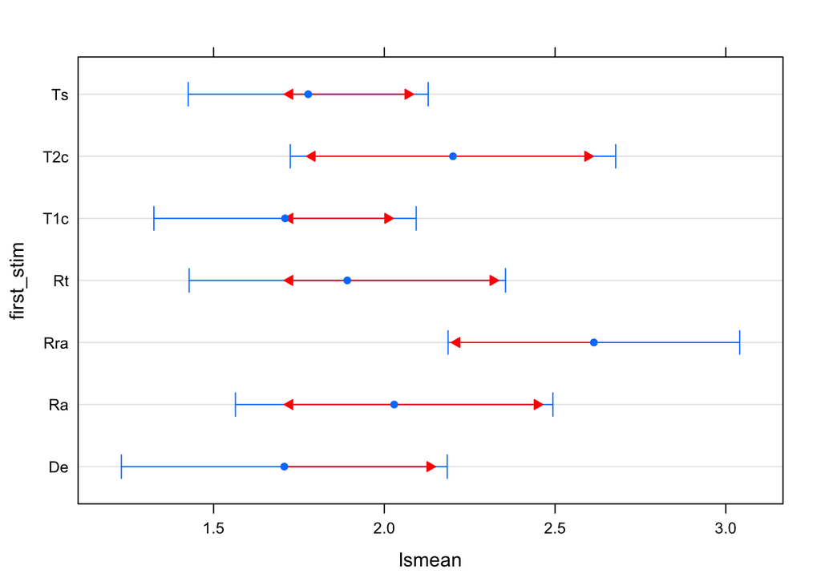

plot of initial interest:

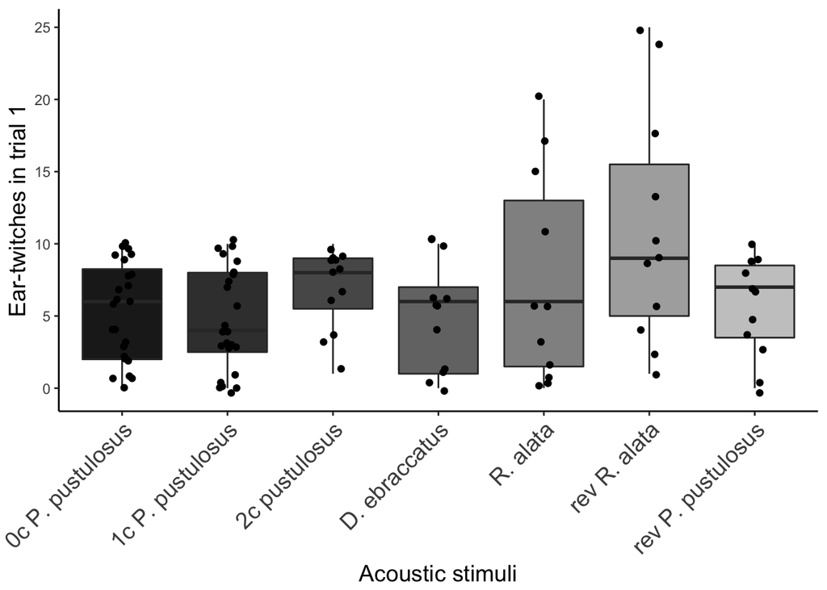

### HABITUATION:

[Data wrangling]

#### model:

Final model:

```
## Generalized linear mixed model fit by maximum likelihood (Laplace
##   Approximation) [glmerMod]
##  Family: poisson  ( log )
## Formula:
## all_tw_call ~ scaled_call_num_2 * primary_stim - 1 + (trial_number |
##     Bat_ID)
##    Data: bat_data
## Control: glmerControl(optimizer = "bobyqa")
##
##      AIC      BIC   logLik deviance df.resid
##   6117.3   6220.2  -3041.6   6083.3     3128
##
## Scaled residuals:
##     Min      1Q  Median      3Q     Max
## -1.4125 -0.6132 -0.2725  0.4021 20.0523
##
## Random effects:
##  Groups Name         Variance Std.Dev. Corr
##  Bat_ID (Intercept)  0.09279  0.3046
##         trial_number 0.02429  0.1559   0.25
## Number of obs: 3145, groups:  Bat_ID, 12
##
## Fixed effects:
##                                   Estimate Std. Error z value Pr(>|z|)
## scaled_call_num_2                 -0.02634    0.06664  -0.395  0.69270
## primary_stimde                     0.45567    0.16577   2.749  0.00598 **
## primary_stimra                    -0.83029    0.19635  -4.229 2.35e-05 ***
## primary_stimrra                   -0.13115    0.16281  -0.806  0.42052
## primary_stimrts                    0.02605    0.16154   0.161  0.87187
## primary_stimts                     0.03142    0.16014   0.196  0.84447
## primary_stimt2c                    0.49393    0.16225   3.044  0.00233 **
## primary_stimt1c                    0.09301    0.16542   0.562  0.57392
## scaled_call_num_2:primary_stimra  -0.98847    0.11788  -8.385  < 2e-16 ***
## scaled_call_num_2:primary_stimrra -0.78466    0.09615  -8.161 3.32e-16 ***
## scaled_call_num_2:primary_stimrts -0.33559    0.10538  -3.185  0.00145 **
## scaled_call_num_2:primary_stimts  -0.20181    0.08102  -2.491  0.01274 *
## scaled_call_num_2:primary_stimt2c -0.12010    0.09392  -1.279  0.20101
## scaled_call_num_2:primary_stimt1c -0.23145    0.08701  -2.660  0.00782 **
## ---
## Signif. codes:  0 '***' 0.001 '**' 0.01 '*' 0.05 '.' 0.1 ' ' 1
```

```
##
## Correlation matrix not shown by default, as p = 14 > 12.
## Use print(x, correlation=TRUE)  or
##   vcov(x)     if you need it
```

ANOVA:

```
## Analysis of Deviance Table (Type II Wald chisquare tests)
##
## Response: all_tw_call
##                                  Chisq Df Pr(>Chisq)
## scaled_call_num_2              183.394  1  < 2.2e-16 ***
## primary_stim                    91.392  7  < 2.2e-16 ***
## scaled_call_num_2:primary_stim 132.923  6  < 2.2e-16 ***
## ---
## Signif. codes:  0 '***' 0.001 '**' 0.01 '*' 0.05 '.' 0.1 ' ' 1
```

#### post hoc comparisons with lsmeans:

log scale:

```
##  primary_stim scaled_call_num_2.trend         SE df  asymp.LCL   asymp.UCL
##  ra                       -1.01480327 0.09723399 NA -1.2053784 -0.82422816
##  rra                      -0.81099822 0.06930461 NA -0.9468328 -0.67516368
##  rts                      -0.36192665 0.08162962 NA -0.5219178 -0.20193553
##  t1c                      -0.25778741 0.05595086 NA -0.3674491 -0.14812573
##  ts                       -0.22814440 0.04607430 NA -0.3184484 -0.13784043
##  t2c                      -0.14643335 0.06618556 NA -0.2761547 -0.01671204
##  de                       -0.02633606 0.06664000 NA -0.1569481  0.10427595
##  .group
##   1
##   1
##    2
##    23
##    23
##    23
##     3
##
## Trends are based on the log (transformed) scale
## Confidence level used: 0.95
## P value adjustment: tukey method for comparing a family of 7 estimates
## significance level used: alpha = 0.05
```

pairwise comparisons:

```
##  contrast     estimate         SE df z.ratio p.value
##  de - ra    0.98846721 0.11787878 NA   8.385  <.0001
##  de - rra   0.78466216 0.09614602 NA   8.161  <.0001
##  de - rts   0.33559059 0.10537671 NA   3.185  0.0244
##  de - ts    0.20180834 0.08101680 NA   2.491  0.1624
##  de - t2c   0.12009730 0.09392248 NA   1.279  0.8619
##  de - t1c   0.23145136 0.08701388 NA   2.660  0.1086
##  ra - rra  -0.20380505 0.11940518 NA  -1.707  0.6114
##  ra - rts  -0.65287662 0.12695619 NA  -5.143  <.0001
##  ra - ts   -0.78665887 0.10759780 NA  -7.311  <.0001
##  ra - t2c  -0.86836991 0.11762220 NA  -7.383  <.0001
##  ra - t1c  -0.75701586 0.11218256 NA  -6.748  <.0001
##  rra - rts -0.44907157 0.10708181 NA  -4.194  0.0005
##  rra - ts  -0.58285382 0.08322239 NA  -7.004  <.0001
##  rra - t2c -0.66456486 0.09583132 NA  -6.935  <.0001
##  rra - t1c -0.55321080 0.08907083 NA  -6.211  <.0001
##  rts - ts  -0.13378225 0.09373487 NA  -1.427  0.7872
##  rts - t2c -0.21549330 0.10508998 NA  -2.051  0.3826
##  rts - t1c -0.10413924 0.09896426 NA  -1.052  0.9416
##  ts - t2c  -0.08171105 0.08064346 NA  -1.013  0.9512
##  ts - t1c   0.02964301 0.07247999 NA   0.409  0.9996
##  t2c - t1c  0.11135406 0.08666622 NA   1.285  0.8592
##
## P value adjustment: tukey method for comparing a family of 7 estimates
```

#### Comparing confidence intervals by other means

Run chunk to compare

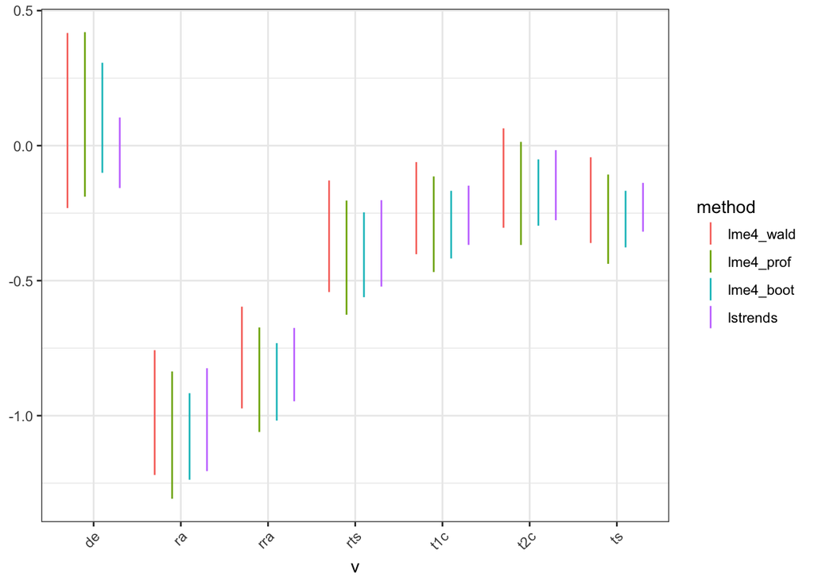

The different methods of generating CI’s have slightly different numbers, but the gist is pretty much the same. de is higher than everything except t2c, rra and ra are lower than everything, and the others are the same and in the middle. Boot maybe has de and t2c being different, Wald has De not different than various forward tungaras.

I’m using lsmean’s values bc they generate tukey adjusted p-vals and sig codes as well

### Plot of just lstrends output

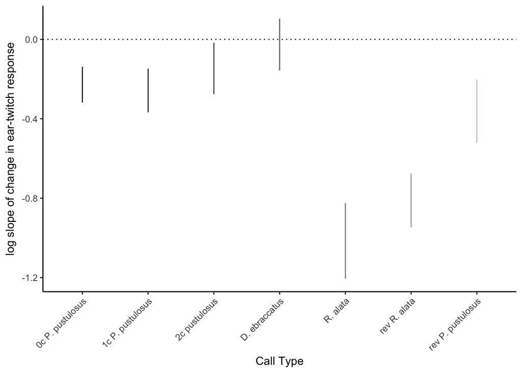

### Discrimination

[data wrangling]

## Summary chart

[output not shown]

### *D. ebracattus* v Tungara:

normality of data:

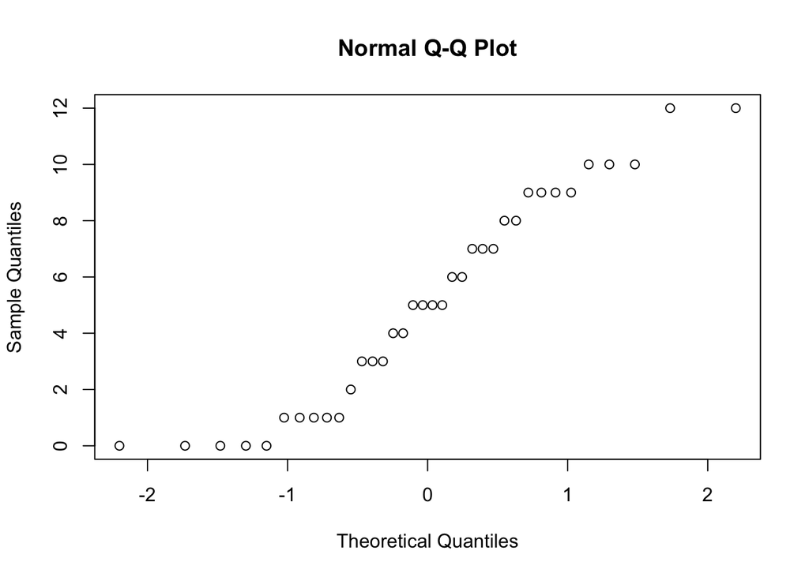

Results of linear mixed model: This models asks whether there is a significant difference between set 5 & 6, and 5 & 7.

```
## Generalized linear mixed model fit by maximum likelihood (Laplace
##   Approximation) [glmerMod]
##  Family: poisson  ( log )
## Formula: all_tw_set ~ as.factor(set_num) + (1 | Bat_ID)
##    Data: subset_de1
##
##      AIC      BIC   logLik deviance df.resid
##    185.6    191.9    -88.8    177.6       32
##
## Scaled residuals:
##     Min      1Q  Median      3Q     Max
## -1.7559 -0.7837 -0.0929  0.4878  2.1284
##
## Random effects:
##  Groups Name        Variance Std.Dev.
##  Bat_ID (Intercept) 0.9339   0.9664
## Number of obs: 36, groups:  Bat_ID, 12
##
## Fixed effects:
##                     Estimate Std. Error z value Pr(>|z|)
## (Intercept)          1.29944    0.31951   4.067 4.76e-05 ***
## as.factor(set_num)6  0.06351    0.17598   0.361    0.718
## as.factor(set_num)7 -0.06782    0.18186  -0.373    0.709
## ---
## Signif. codes:  0 '***' 0.001 '**' 0.01 '*' 0.05 '.' 0.1 ' ' 1
##
## Correlation of Fixed Effects:
##             (Intr) a.(_)6
## as.fctr(_)6 -0.284
## as.fctr(_)7 -0.275  0.499
```

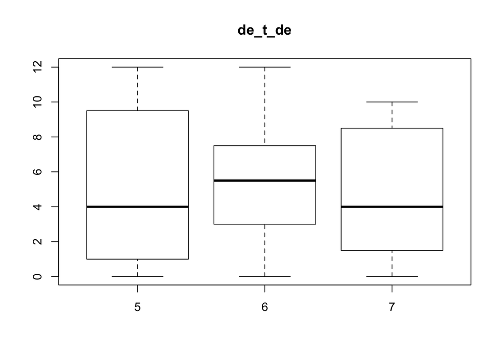

```
##  set_num   lsmean        SE df asymp.LCL asymp.UCL .group
##        7 1.231612 0.3212568 NA 0.6019604  1.861264  1
##        5 1.299436 0.3195071 NA 0.6732136  1.925658  1
##        6 1.362946 0.3179649 NA 0.7397461  1.986146  1
##
## Results are given on the log (not the response) scale.
## Confidence level used: 0.95
## P value adjustment: tukey method for comparing a family of 3 estimates
## significance level used: alpha = 0.05
```

```
##  contrast    estimate        SE df z.ratio p.value
##  5 - 6    -0.06350984 0.1759815 NA  -0.361  0.9307
##  5 - 7     0.06782382 0.1818619 NA   0.373  0.9262
##  6 - 7     0.13133367 0.1791386 NA   0.733  0.7438
##
## Results are given on the log (not the response) scale.
## P value adjustment: tukey method for comparing a family of 3 estimates
```

### *Rhinella alata* v Tungara

normality of data:

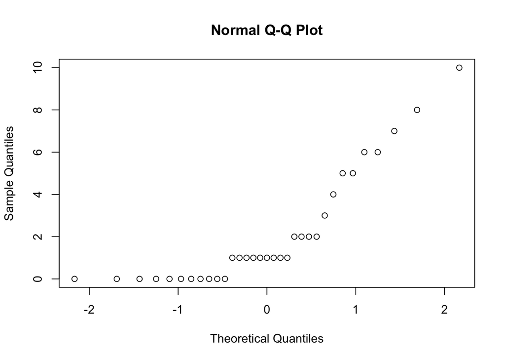

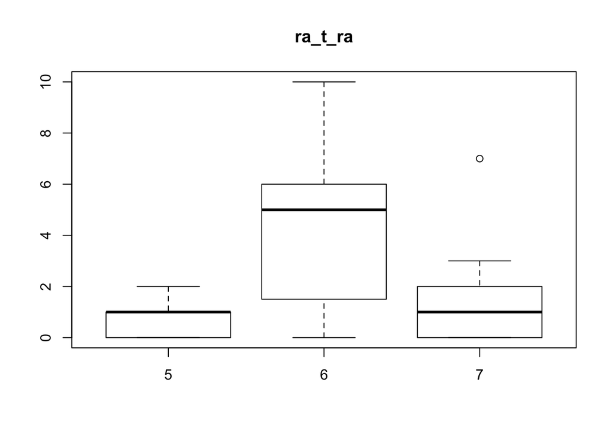

```
##  set_num     lsmean        SE df  asymp.LCL asymp.UCL .group
##        5 -0.6555376 0.4327947 NA -1.5037996 0.1927244  1
##        7  0.2317656 0.3262518 NA -0.4076761 0.8712073  1
##        6  1.2486998 0.2651533 NA  0.7290088 1.7683908   2
##
## Results are given on the log (not the response) scale.
## Confidence level used: 0.95
## P value adjustment: tukey method for comparing a family of 3 estimates
## significance level used: alpha = 0.05
```

```
##  contrast   estimate        SE df z.ratio p.value
##  5 - 6    -1.9042374 0.3974377 NA  -4.791  <.0001
##  5 - 7    -0.8873031 0.4405572 NA  -2.014  0.1088
##  6 - 7     1.0169342 0.2776431 NA   3.663  0.0007
##
## Results are given on the log (not the response) scale.
## P value adjustment: tukey method for comparing a family of 3 estimates
```

There is evidence for descrimination between rhinella alata and tungara frogs

### Reversed *R. alata* v tungara

Normality of data:

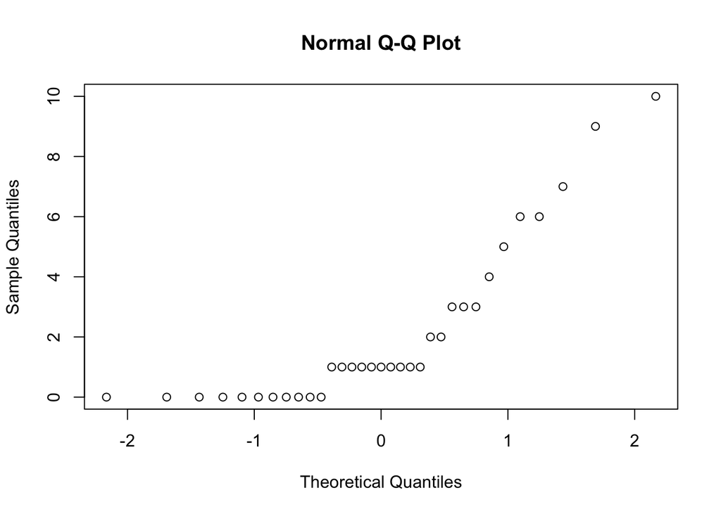

```
## Generalized linear mixed model fit by maximum likelihood (Laplace
##   Approximation) [glmerMod]
##  Family: poisson  ( log )
## Formula: all_tw_set ~ as.factor(set_num) + (1 | Bat_ID)
##    Data: subset_rra1
##
##      AIC      BIC   logLik deviance df.resid
##    113.8    119.8    -52.9    105.8       29
##
## Scaled residuals:
##     Min      1Q  Median      3Q     Max
## -1.6110 -0.7629 -0.1414  0.5437  1.5878
##
## Random effects:
##  Groups Name        Variance Std.Dev.
##  Bat_ID (Intercept) 0.305    0.5523
## Number of obs: 33, groups:  Bat_ID, 11
##
## Fixed effects:
##                     Estimate Std. Error z value Pr(>|z|)
## (Intercept)          -0.5961     0.4153  -1.435    0.151
## as.factor(set_num)6   2.0053     0.3963   5.060 4.19e-07 ***
## as.factor(set_num)7   0.4520     0.4759   0.950    0.342
## ---
## Signif. codes:  0 '***' 0.001 '**' 0.01 '*' 0.05 '.' 0.1 ' ' 1
##
## Correlation of Fixed Effects:
##             (Intr) a.(_)6
## as.fctr(_)6 -0.841
## as.fctr(_)7 -0.700  0.734
```

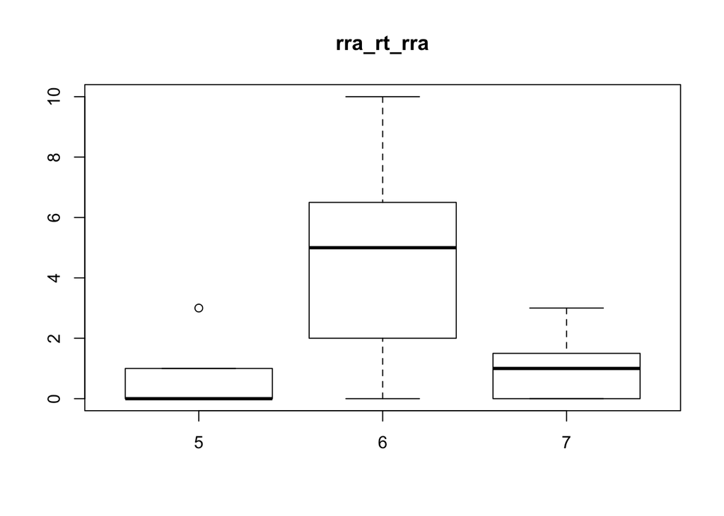

```
##  set_num     lsmean        SE df  asymp.LCL asymp.UCL .group
##        5 -0.5960597 0.4152897 NA -1.4100126 0.2178932  1
##        7 -0.1440627 0.3494734 NA -0.8290180 0.5408926  1
##        6  1.4092772 0.2295279 NA  0.9594107 1.8591437   2
##
## Results are given on the log (not the response) scale.
## Confidence level used: 0.95
## P value adjustment: tukey method for comparing a family of 3 estimates
## significance level used: alpha = 0.05
```

```
##  contrast  estimate        SE df z.ratio p.value
##  5 - 6    -2.005337 0.3962928 NA  -5.060  <.0001
##  5 - 7    -0.451997 0.4759165 NA  -0.950  0.6087
##  6 - 7     1.553340 0.3266712 NA   4.755  <.0001
##
## Results are given on the log (not the response) scale.
## P value adjustment: tukey method for comparing a family of 3 estimates
```

There is evidence for descrimination between 5 and 6, but not for dishabituation (5 and 7). There was very steep habituation to reversed rhinella alata, which might explain a part of this trend.

So, clearly they discriminate / can discriminate to the sounds of the reversed rhinella and the reversed tungara.

### reversed tungara v reversed *R. alata*

Normality of data:

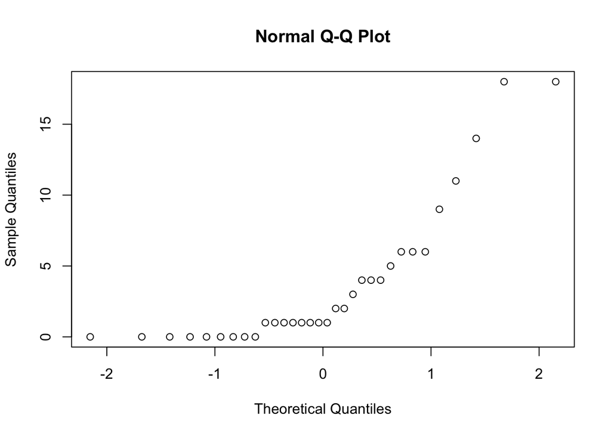

This linear mixed model may not be appropriate for this test given its terribly right-skewed distribution

```
## Data: subset_rt1
## Models:
## rt_desc_glm: all_tw_set ~ as.factor(set_num) + (1 | Bat_ID)
## rt_desc_glm.nb: all_tw_set ~ as.factor(set_num) + (1 | Bat_ID)
##                Df    AIC    BIC  logLik deviance  Chisq Chi Df Pr(>Chisq)
## rt_desc_glm     4 201.09 206.96 -96.547   193.09
## rt_desc_glm.nb  5 159.81 167.14 -74.907   149.81 43.281      1  4.743e-11
##
## rt_desc_glm
## rt_desc_glm.nb ***
## ---
## Signif. codes:  0 '***' 0.001 '**' 0.01 '*' 0.05 '.' 0.1 ' ' 1
```

```
## [1] TRUE
```

```
## Generalized linear mixed model fit by maximum likelihood (Laplace
##   Approximation) [glmerMod]
##  Family: poisson  ( log )
## Formula: all_tw_set ~ as.factor(set_num) + (1 | Bat_ID)
##    Data: subset_rt1
##
##      AIC      BIC   logLik deviance df.resid
##    201.1    207.0    -96.5    193.1       28
##
## Scaled residuals:
##     Min      1Q  Median      3Q     Max
## -2.3675 -0.9938 -0.4938  1.0661  3.7317
##
## Random effects:
##  Groups Name        Variance Std.Dev.
##  Bat_ID (Intercept) 0.5036   0.7097
## Number of obs: 32, groups:  Bat_ID, 11
##
## Fixed effects:
##                     Estimate Std. Error z value Pr(>|z|)
## (Intercept)           0.5280     0.3131   1.687 0.091663 .
## as.factor(set_num)6   0.9162     0.2475   3.702 0.000214 ***
## as.factor(set_num)7   0.3686     0.2959   1.246 0.212887
## ---
## Signif. codes:  0 '***' 0.001 '**' 0.01 '*' 0.05 '.' 0.1 ' ' 1
##
## Correlation of Fixed Effects:
##             (Intr) a.(_)6
## as.fctr(_)6 -0.589
## as.fctr(_)7 -0.532  0.627
```

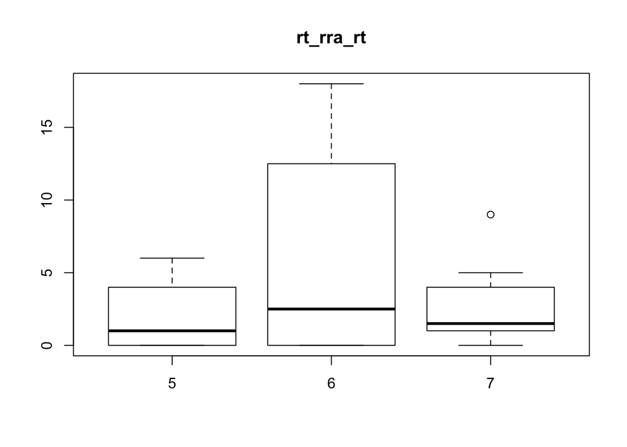

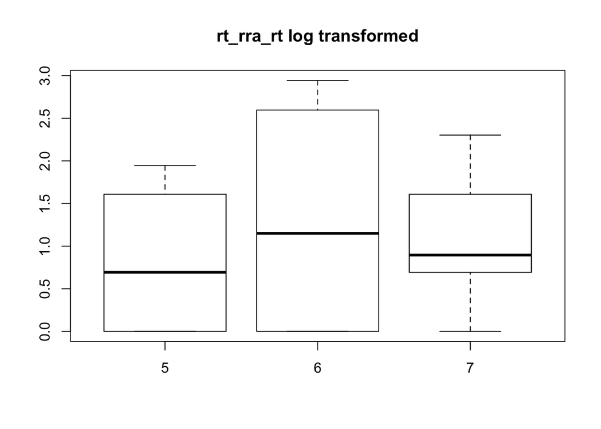

```
##  set_num    lsmean        SE df   asymp.LCL asymp.UCL .group
##        5 0.5280375 0.3130617 NA -0.08555214  1.141627  1
##        7 0.8966216 0.2949548 NA  0.31852089  1.474722  12
##        6 1.4441915 0.2607685 NA  0.93309473  1.955288   2
##
## Results are given on the log (not the response) scale.
## Confidence level used: 0.95
## P value adjustment: tukey method for comparing a family of 3 estimates
## significance level used: alpha = 0.05
```

```
##  contrast   estimate        SE df z.ratio p.value
##  5 - 6    -0.9161540 0.2474623 NA  -3.702  0.0006
##  5 - 7    -0.3685841 0.2958929 NA  -1.246  0.4262
##  6 - 7     0.5475699 0.2386497 NA   2.294  0.0566
##
## Results are given on the log (not the response) scale.
## P value adjustment: tukey method for comparing a family of 3 estimates
```

So again, there is discrimination, if not dishabituation between reversed tungara and reversed alata.

### Tungara v *D. ebracattus*

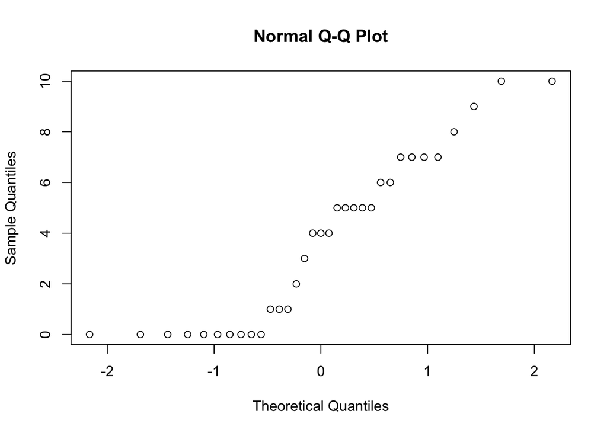

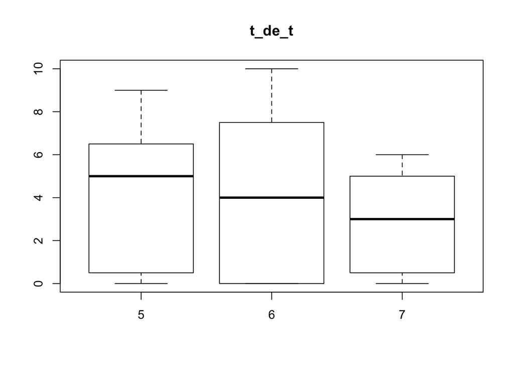

```
##  set_num    lsmean        SE df   asymp.LCL asymp.UCL .group
##        7 0.6726080 0.3746942 NA -0.06177913  1.406995  1
##        5 0.9521921 0.3644006 NA  0.23798019  1.666404  1
##        6 1.1506448 0.3585282 NA  0.44794255  1.853347  1
##
## Results are given on the log (not the response) scale.
## Confidence level used: 0.95
## P value adjustment: tukey method for comparing a family of 3 estimates
## significance level used: alpha = 0.05
```

```
##  contrast   estimate        SE df z.ratio p.value
##  5 - 6    -0.1984527 0.2071821 NA  -0.958  0.6036
##  5 - 7     0.2795841 0.2340465 NA   1.195  0.4564
##  6 - 7     0.4780368 0.2247942 NA   2.127  0.0845
##
## Results are given on the log (not the response) scale.
## P value adjustment: tukey method for comparing a family of 3 estimates
```

There is no evidence for descrimination between tungara and dendrobates Perhaps/ likley due to high overall responses

### Tungara v R. alata

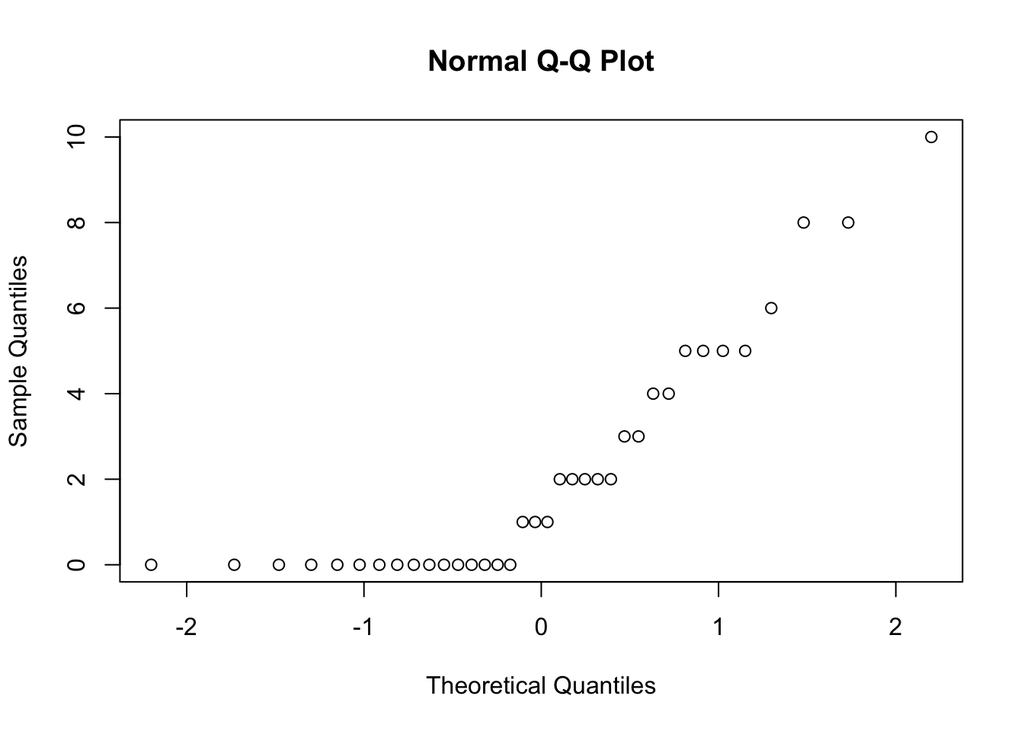

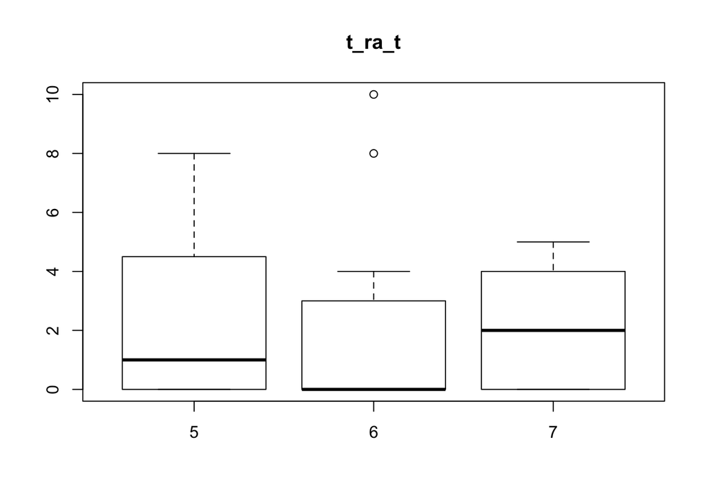

```
## Generalized linear mixed model fit by maximum likelihood (Laplace
##   Approximation) [glmerMod]
##  Family: poisson  ( log )
## Formula: all_tw_set ~ set_num + (1 | Bat_ID)
##    Data: subset_t_ra1
## Control: glmerControl(optimizer = "bobyqa")
##
##      AIC      BIC   logLik deviance df.resid
##    152.2    157.0    -73.1    146.2       33
##
## Scaled residuals:
##     Min      1Q  Median      3Q     Max
## -1.7986 -0.7990 -0.5584  0.5306  3.5531
##
## Random effects:
##  Groups Name        Variance Std.Dev.
##  Bat_ID (Intercept) 1.371    1.171
## Number of obs: 36, groups:  Bat_ID, 12
##
## Fixed effects:
##             Estimate Std. Error z value Pr(>|z|)
## (Intercept)  0.59281    0.89296   0.664    0.507
## set_num     -0.05699    0.13447  -0.424    0.672
##
## Correlation of Fixed Effects:
##         (Intr)
## set_num -0.898
```

This chunk isn’t knittingn for some reason: eval=false for now

No discimination between treatments detected. (generalization or dishabituation)

## Complex tungara v simple tungara

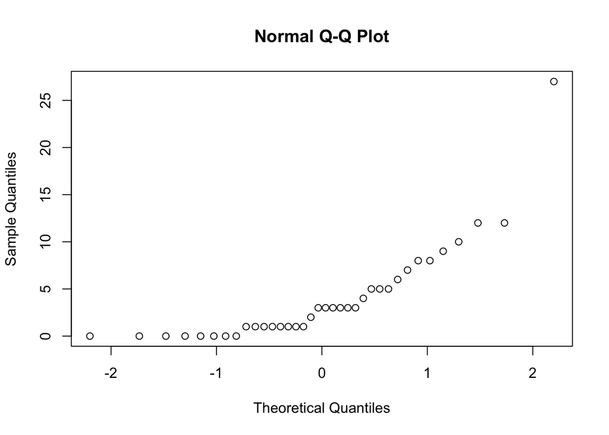

```
## Generalized linear mixed model fit by maximum likelihood (Laplace
##   Approximation) [glmerMod]
##  Family: poisson  ( log )
## Formula: all_tw_set ~ as.factor(set_num) + (1 | Bat_ID)
##    Data: subset_tc1
##
##      AIC      BIC   logLik deviance df.resid
##    181.7    188.1    -86.9    173.7       32
##
## Scaled residuals:
##     Min      1Q  Median      3Q     Max
## -2.2714 -0.7055 -0.0501  0.5760  3.3764
##
## Random effects:
##  Groups Name        Variance Std.Dev.
##  Bat_ID (Intercept) 1.595    1.263
## Number of obs: 36, groups:  Bat_ID, 12
##
## Fixed effects:
##                     Estimate Std. Error z value Pr(>|z|)
## (Intercept)           1.0849     0.4076   2.662 0.007771 **
## as.factor(set_num)6  -0.7087     0.2125  -3.334 0.000856 ***
## as.factor(set_num)7  -0.2826     0.1862  -1.517 0.129149
## ---
## Signif. codes:  0 '***' 0.001 '**' 0.01 '*' 0.05 '.' 0.1 ' ' 1
##
## Correlation of Fixed Effects:
##             (Intr) a.(_)6
## as.fctr(_)6 -0.172
## as.fctr(_)7 -0.196  0.377
```

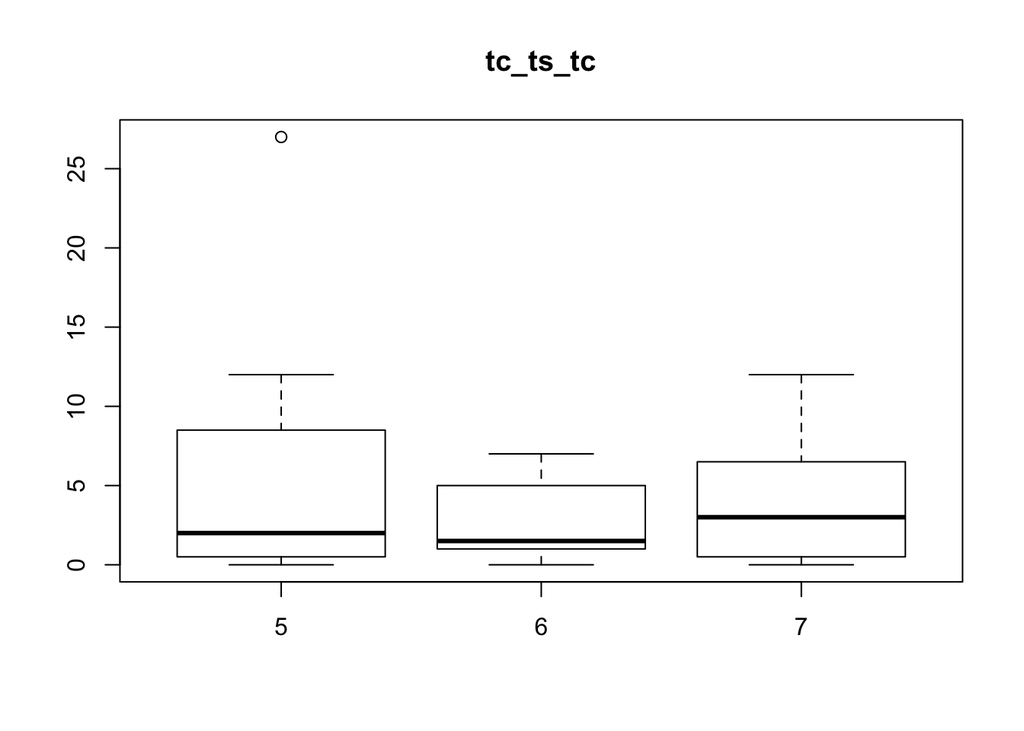

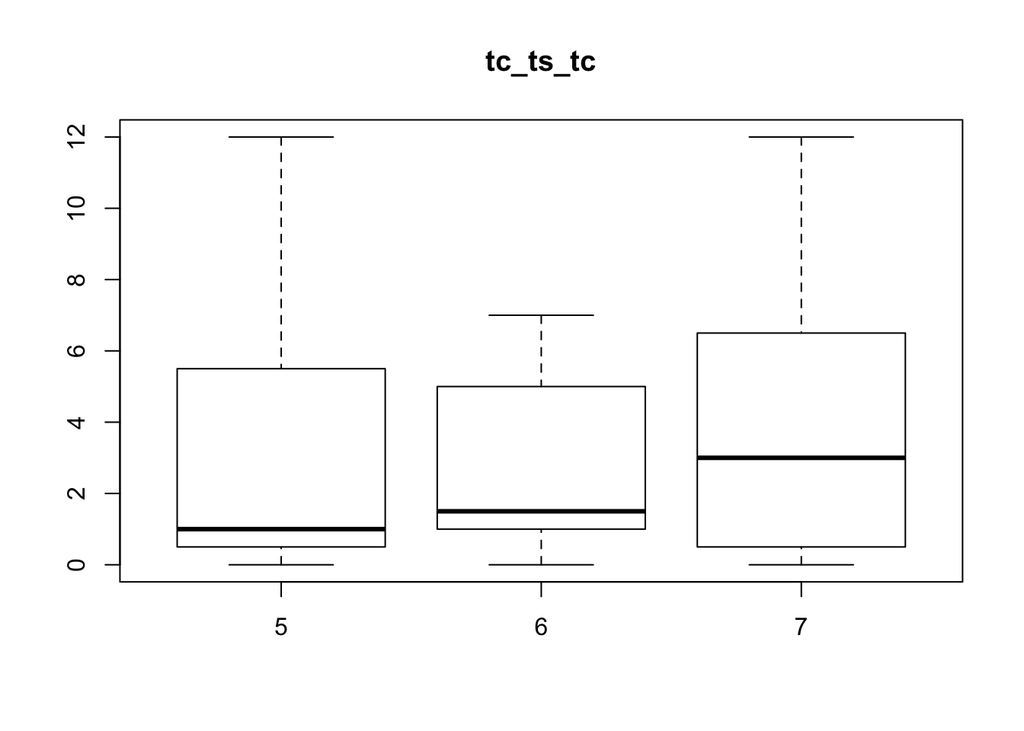

```
## Generalized linear mixed model fit by maximum likelihood (Laplace
##   Approximation) [glmerMod]
##  Family: poisson  ( log )
## Formula: all_tw_set.no ~ as.factor(set_num) + (1 | Bat_ID)
##    Data: subset_tc1
##
##      AIC      BIC   logLik deviance df.resid
##    148.2    154.4    -70.1    140.2       31
##
## Scaled residuals:
##     Min      1Q  Median      3Q     Max
## -1.3100 -0.6434 -0.1235  0.3458  1.7932
##
## Random effects:
##  Groups Name        Variance Std.Dev.
##  Bat_ID (Intercept) 1.289    1.135
## Number of obs: 35, groups:  Bat_ID, 12
##
## Fixed effects:
##                     Estimate Std. Error z value Pr(>|z|)
## (Intercept)           0.7078     0.3880   1.824   0.0681 .
## as.factor(set_num)6  -0.2459     0.2374  -1.036   0.3003
## as.factor(set_num)7   0.1802     0.2142   0.841   0.4002
## ---
## Signif. codes:  0 '***' 0.001 '**' 0.01 '*' 0.05 '.' 0.1 ' ' 1
##
## Correlation of Fixed Effects:
##             (Intr) a.(_)6
## as.fctr(_)6 -0.286
## as.fctr(_)7 -0.317  0.516
```

with outlier

```
##  set_num    lsmean        SE df    asymp.LCL asymp.UCL .group
##        6 0.3762773 0.4260228 NA -0.458712095  1.211267  1
##        7 0.8023686 0.4135125 NA -0.008100967  1.612838  12
##        5 1.0849322 0.4075858 NA  0.286078688  1.883786   2
##
## Results are given on the log (not the response) scale.
## Confidence level used: 0.95
## P value adjustment: tukey method for comparing a family of 3 estimates
## significance level used: alpha = 0.05
```

```
##  contrast   estimate        SE df z.ratio p.value
##  5 - 6     0.7086549 0.2125466 NA   3.334  0.0025
##  5 - 7     0.2825637 0.1862073 NA   1.517  0.2826
##  6 - 7    -0.4260913 0.2237016 NA  -1.905  0.1373
##
## Results are given on the log (not the response) scale.
## P value adjustment: tukey method for comparing a family of 3 estimates
```

without outlier

```
##  set_num    lsmean        SE df   asymp.LCL asymp.UCL .group
##        6 0.4619399 0.3926453 NA -0.30763082  1.231511  1
##        5 0.7077959 0.3880367 NA -0.05274197  1.468334  1
##        7 0.8880340 0.3791133 NA  0.14498561  1.631082  1
##
## Results are given on the log (not the response) scale.
## Confidence level used: 0.95
## P value adjustment: tukey method for comparing a family of 3 estimates
## significance level used: alpha = 0.05
```

```
##  contrast   estimate        SE df z.ratio p.value
##  5 - 6     0.2458560 0.2373659 NA   1.036  0.5542
##  5 - 7    -0.1802381 0.2142408 NA  -0.841  0.6773
##  6 - 7    -0.4260941 0.2230671 NA  -1.910  0.1358
##
## Results are given on the log (not the response) scale.
## P value adjustment: tukey method for comparing a family of 3 estimates
```

If this is accurate, it is probable that discrimination is obscured by simple calls being less salient stimuli, so the interuption in habituation is masked by lower overall interest in the simple call. See the inverse treatment:

## Simple tungara against complex tungara call

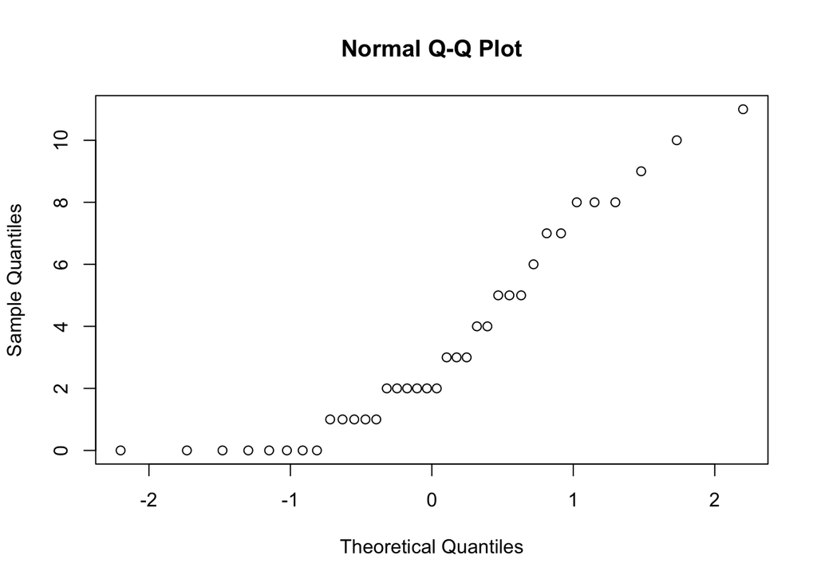

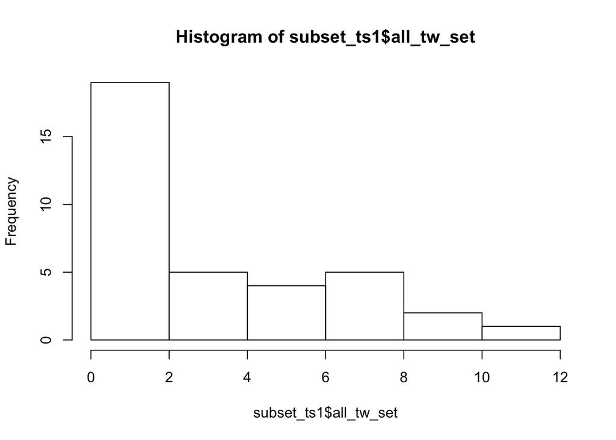

```
## Generalized linear mixed model fit by maximum likelihood (Laplace
##   Approximation) [glmerMod]
##  Family: poisson  ( log )
## Formula: all_tw_set ~ as.factor(set_num) + (1 | Bat_ID)
##    Data: subset_ts1
##
##      AIC      BIC   logLik deviance df.resid
##    164.5    170.9    -78.3    156.5       32
##
## Scaled residuals:
##     Min      1Q  Median      3Q     Max
## -1.4142 -0.7839 -0.2993  0.6522  2.3175
##
## Random effects:
##  Groups Name        Variance Std.Dev.
##  Bat_ID (Intercept) 0.5967   0.7725
## Number of obs: 36, groups:  Bat_ID, 12
##
## Fixed effects:
##                     Estimate Std. Error z value Pr(>|z|)
## (Intercept)           0.5145     0.3058   1.682 0.092489 .
## as.factor(set_num)6   0.8850     0.2294   3.858 0.000114 ***
## as.factor(set_num)7   0.2683     0.2564   1.046 0.295365
## ---
## Signif. codes:  0 '***' 0.001 '**' 0.01 '*' 0.05 '.' 0.1 ' ' 1
##
## Correlation of Fixed Effects:
##             (Intr) a.(_)6
## as.fctr(_)6 -0.531
## as.fctr(_)7 -0.475  0.633
```

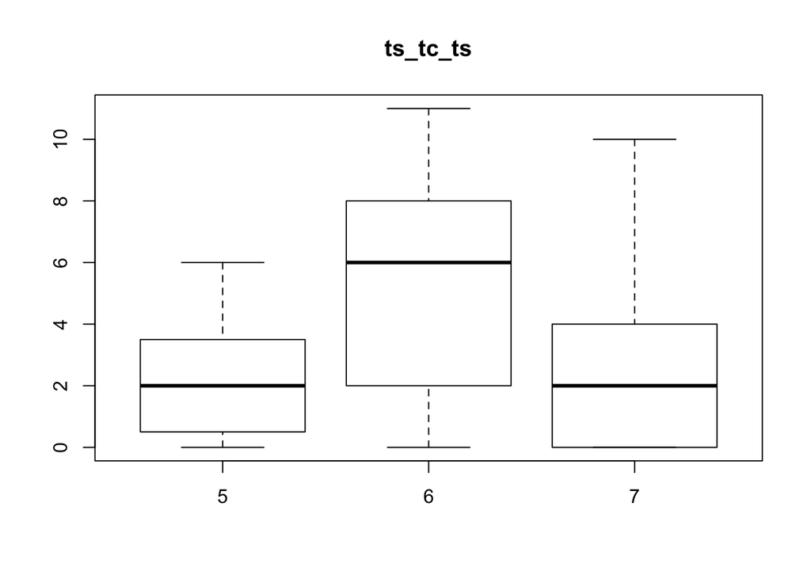

```
##  set_num    lsmean        SE df   asymp.LCL asymp.UCL .group
##        5 0.5144599 0.3057871 NA -0.08487186  1.113792  1
##        7 0.7827355 0.2911044 NA  0.21218139  1.353290  1
##        6 1.3995056 0.2676400 NA  0.87494075  1.924070   2
##
## Results are given on the log (not the response) scale.
## Confidence level used: 0.95
## P value adjustment: tukey method for comparing a family of 3 estimates
## significance level used: alpha = 0.05
```

```
##  contrast   estimate        SE df z.ratio p.value
##  5 - 6    -0.8850456 0.2293837 NA  -3.858  0.0003
##  5 - 7    -0.2682755 0.2563736 NA  -1.046  0.5475
##  6 - 7     0.6167701 0.2094107 NA   2.945  0.0091
##
## Results are given on the log (not the response) scale.
## P value adjustment: tukey method for comparing a family of 3 estimates
```

This shows that bats discriminate between complex and simple tungara calls (0c v 2c). There is clear evidence of discrimination (lack of stimulus genrealization), but not of dishabituation Note how discrimination is more apparent when the less salient stimulus is the one that is being habituated. ((Also, more habituation=more evidence of discrimination))

## Tungara “A” v Tungara “B” (or the id of individuals trials)

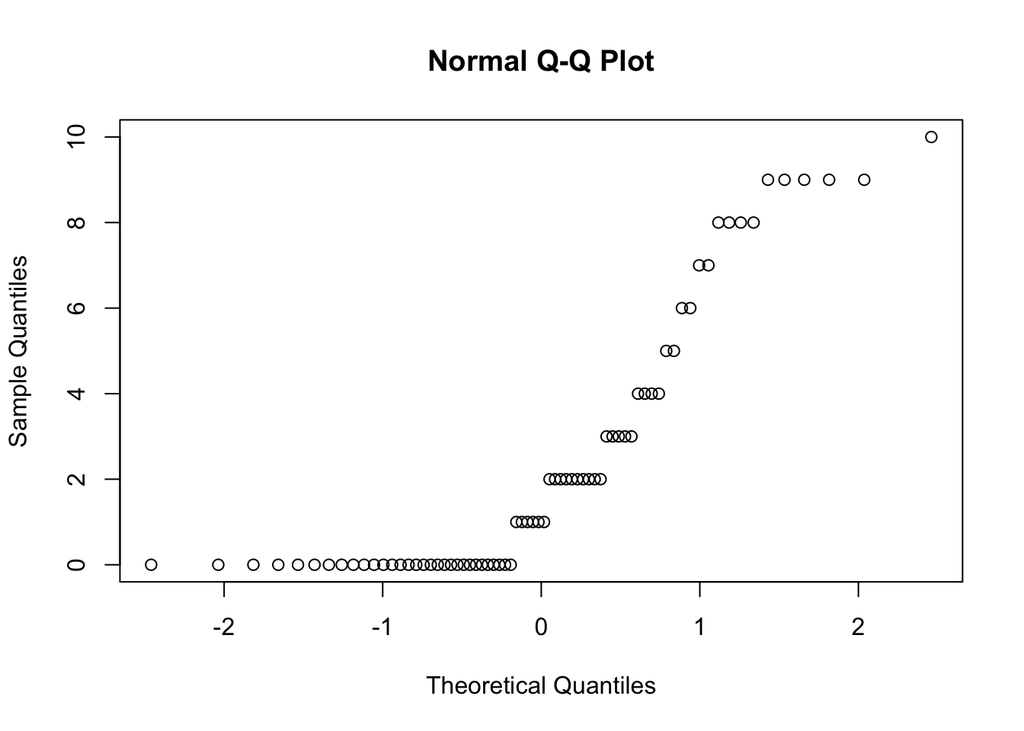

```
## Generalized linear mixed model fit by maximum likelihood (Laplace
##   Approximation) [glmerMod]
##  Family: poisson  ( log )
## Formula: all_tw_set ~ as.factor(set_num) + (1 | Bat_ID)
##    Data: subset_tia1
##
##      AIC      BIC   logLik deviance df.resid
##    278.3    287.4   -135.1    270.3       68
##
## Scaled residuals:
##     Min      1Q  Median      3Q     Max
## -1.7873 -0.9033 -0.5710  0.9016  3.6872
##
## Random effects:
##  Groups Name        Variance Std.Dev.
##  Bat_ID (Intercept) 1.373    1.172
## Number of obs: 72, groups:  Bat_ID, 12
##
## Fixed effects:
##                     Estimate Std. Error z value Pr(>|z|)
## (Intercept)          0.41581    0.37456   1.110   0.2669
## as.factor(set_num)6  0.01504    0.17116   0.088   0.9300
## as.factor(set_num)7 -0.33951    0.18836  -1.802   0.0715 .
## ---
## Signif. codes:  0 '***' 0.001 '**' 0.01 '*' 0.05 '.' 0.1 ' ' 1
##
## Correlation of Fixed Effects:
##             (Intr) a.(_)6
## as.fctr(_)6 -0.230
## as.fctr(_)7 -0.209  0.458
```

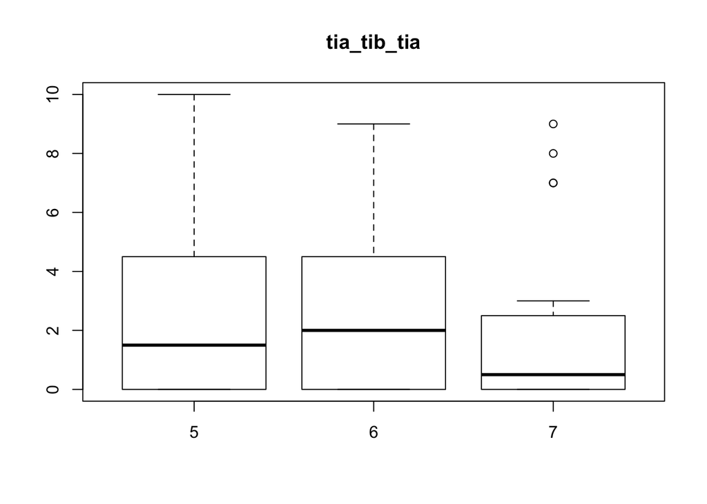

significant differences and pairwise contrasts:

```
##  set_num     lsmean        SE df  asymp.LCL asymp.UCL .group
##        7 0.07630563 0.3824394 NA -0.6732619 0.8258732  1
##        5 0.41581291 0.3745586 NA -0.3183084 1.1499342  1
##        6 0.43085125 0.3742644 NA -0.3026935 1.1643960  1
##
## Results are given on the log (not the response) scale.
## Confidence level used: 0.95
## P value adjustment: tukey method for comparing a family of 3 estimates
## significance level used: alpha = 0.05
```

```
##  contrast    estimate        SE df z.ratio p.value
##  5 - 6    -0.01503834 0.1711573 NA  -0.088  0.9958
##  5 - 7     0.33950728 0.1883637 NA   1.802  0.1688
##  6 - 7     0.35454562 0.1877782 NA   1.888  0.1421
##
## Results are given on the log (not the response) scale.
## P value adjustment: tukey method for comparing a family of 3 estimates
```

There is no apparent discrimination between individual tungaras. Removing the possible outliers would only make it less likely to show dishabituation

### Plots of whole trials

[Data wrangling]

[de_t_de]

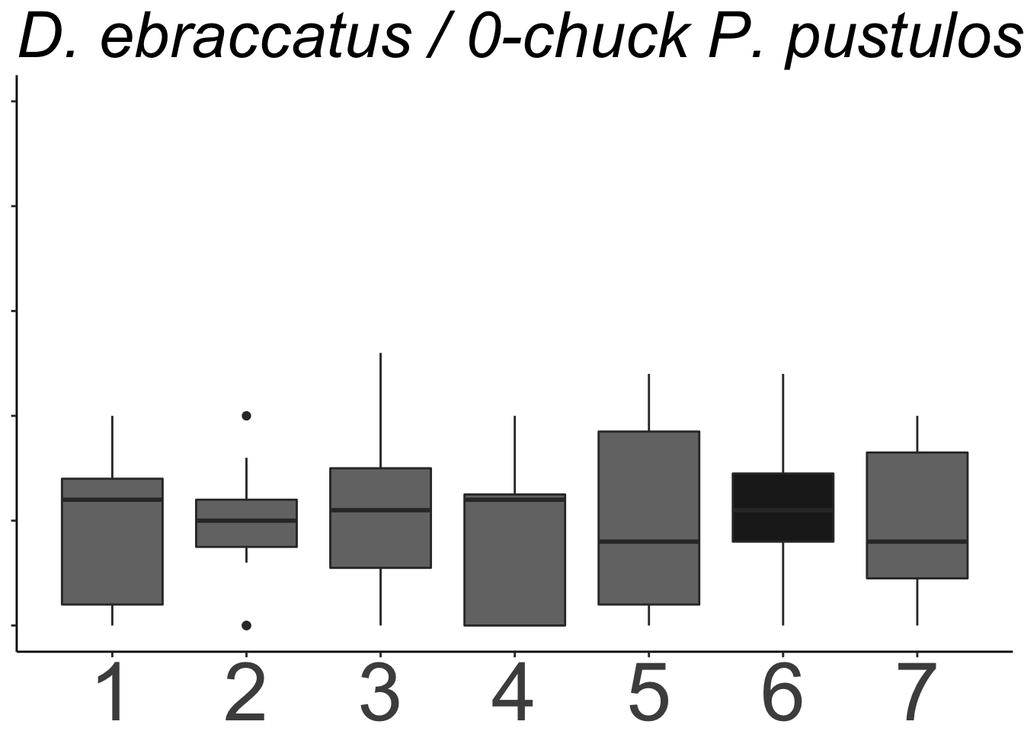

t_de

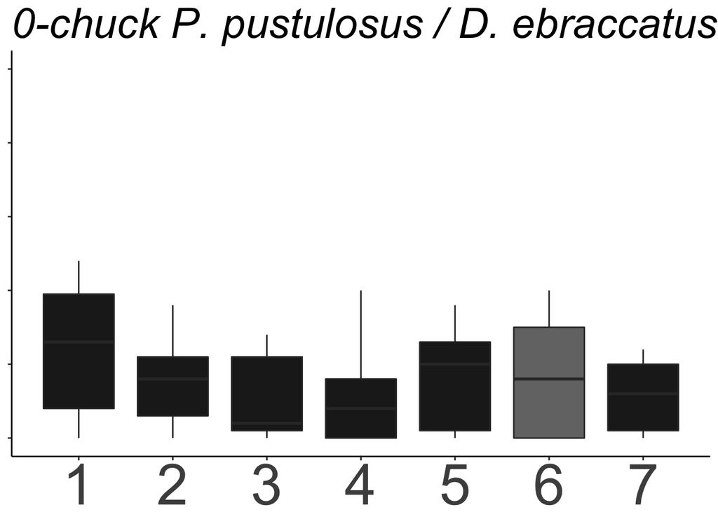

[ra_t_ra]

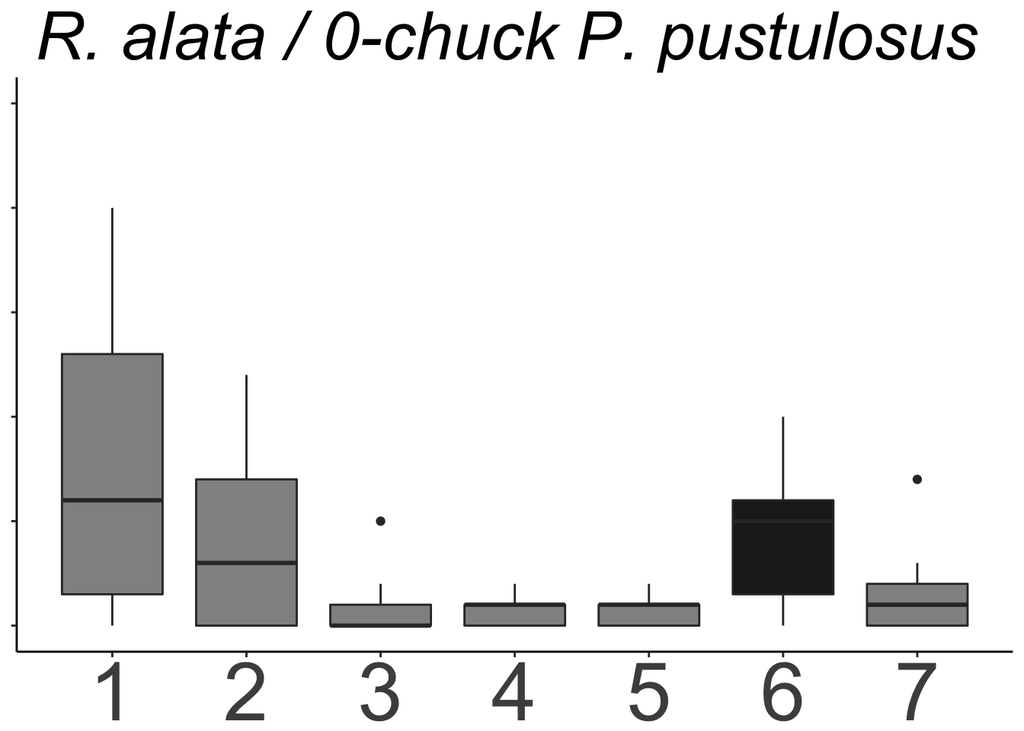

[t_ra_t]

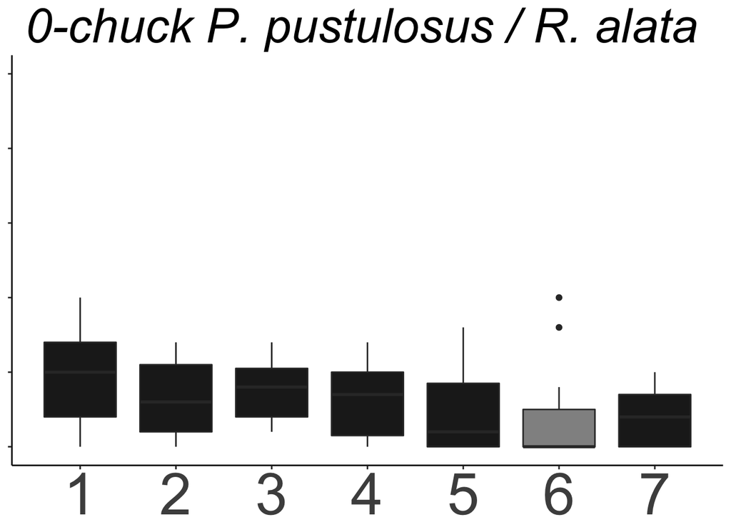